# Exam 2 Chapters 4 and 5

## by Ledin Menjivar

### Task 1

**1.**

```r
head(iris)
```

```
##   Sepal.Length Sepal.Width Petal.Length Petal.Width Species
## 1          5.1         3.5          1.4         0.2  setosa
## 2          4.9         3.0          1.4         0.2  setosa
## 3          4.7         3.2          1.3         0.2  setosa
## 4          4.6         3.1          1.5         0.2  setosa
## 5          5.0         3.6          1.4         0.2  setosa
## 6          5.4         3.9          1.7         0.4  setosa
```

```r
str(iris)
```

```
## 'data.frame':    150 obs. of  5 variables:
##  $ Sepal.Length: num  5.1 4.9 4.7 4.6 5 5.4 4.6 5 4.4 4.9 ...
##  $ Sepal.Width : num  3.5 3 3.2 3.1 3.6 3.9 3.4 3.4 2.9 3.1 ...
##  $ Petal.Length: num  1.4 1.4 1.3 1.5 1.4 1.7 1.4 1.5 1.4 1.5 ...
##  $ Petal.Width : num  0.2 0.2 0.2 0.2 0.2 0.4 0.3 0.2 0.2 0.1 ...
##  $ Species     : Factor w/ 3 levels "setosa","versicolor",..: 1 1 1 1 1 1 1 1 1 1 ...
```

```r
summary(iris)
```

```
##   Sepal.Length    Sepal.Width     Petal.Length    Petal.Width
##  Min.   :4.300   Min.   :2.000   Min.   :1.000   Min.   :0.100
##  1st Qu.:5.100   1st Qu.:2.800   1st Qu.:1.600   1st Qu.:0.300
##  Median :5.800   Median :3.000   Median :4.350   Median :1.300
##  Mean   :5.843   Mean   :3.057   Mean   :3.758   Mean   :1.199
##  3rd Qu.:6.400   3rd Qu.:3.300   3rd Qu.:5.100   3rd Qu.:1.800
##  Max.   :7.900   Max.   :4.400   Max.   :6.900   Max.   :2.500
##        Species
##  setosa    :50
##  versicolor:50
##  virginica :50
##
##
##
```

**2.** The dataset iris contains 150 observations for 3 different flowers setosa, versicolor and virginica. And it contains the measurements for sepal length and width and the measurements for petal length and width. These measurements are in centimeters for the different species of flowers. The help() function was also used.

**3.** The head() function will by default return the first 6 observations within our dataset.The number of obeservations can also be specified with heaad(iris,n) where n is the number of observations to be returned.

**4**

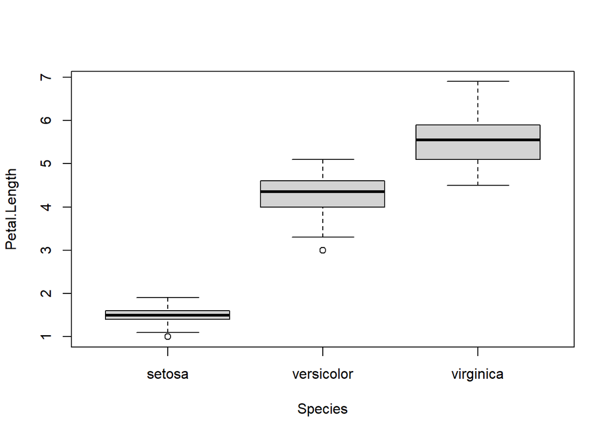

```r
boxplot(formula=Petal.Length~Species, data = iris)
```

```r
boxplot(formula=Petal.Length~Species, data = iris, plot=F)
```

```
## $stats
##      [,1] [,2] [,3]
## [1,]  1.1 3.30 4.50
## [2,]  1.4 4.00 5.10
## [3,]  1.5 4.35 5.55
## [4,]  1.6 4.60 5.90
## [5,]  1.9 5.10 6.90
##
## $n
## [1] 50 50 50
##
## $conf
##          [,1]     [,2]     [,3]
## [1,] 1.455311 4.215933 5.371243
## [2,] 1.544689 4.484067 5.728757
##
## $out
## [1] 1 3
##
## $group
## [1] 1 2
##
## $names
## [1] "setosa"     "versicolor" "virginica"
```

The assigned code for this problem returns creates a boxplot which shows petal lengths for each species of flower in the dataset iris. By setting $plot=F$ we can also see the actual statistical values used to create each boxplot. From the boxplot figure we can see we have two outliers, 1 in setosa species and another in the versicolor species of flowers. We can also see that we have the medians: $setosa= 1.5cm$, $versicolor=4.35cm$ and $virginica=5.55cm$. Thus we can determine that the species virginica will have a longer petal length on average. From our diagram we can also see that for the setosa species we have smaller upper and lower extremums than the other two flowers which we have lower extremum for setosa $= 1.1cm$ and upper extremum for setosa = $1.9cm$. Thus we can also determine that the setosa species will always have smaller petal lengths than that of the other two species. We can also see that we may sometimes have longer petal lengths for the species versicolor than that of the virginica flower because of: upper extremum of versicolor = $5.10cm$ and we have lower extremum of virginica$=4.50$.

**5.**

```r
model1 <- manova(cbind(Sepal.Length,Sepal.Width) ~ Species, data=iris)
```

**6.** The code chunk in question $5$ tests for variance when there are more than one dependent variables. Here our dependent variables are Sepal.Length and Sepal.Width. And our independent variable is Species.

**7.** No. Because there is no print or summary statement to show the results.

**8.**

```r
summary.aov(model1)
```

```
##  Response Sepal.Length :
##              Df Sum Sq Mean Sq F value    Pr(>F)
## Species       2 63.212  31.606  119.26 < 2.2e-16 ***
## Residuals   147 38.956   0.265
## ---
## Signif. codes:  0 '***' 0.001 '**' 0.01 '*' 0.05 '.' 0.1 ' ' 1
##
##  Response Sepal.Width :
##              Df Sum Sq Mean Sq F value    Pr(>F)
## Species       2 11.345  5.6725   49.16 < 2.2e-16 ***
## Residuals   147 16.962  0.1154
## ---
## Signif. codes:  0 '***' 0.001 '**' 0.01 '*' 0.05 '.' 0.1 ' ' 1
```

### Task 2

**1**

```r
data(iris)
iris
```

[output not shown]

[output cut: 136 more lines]

```r
#install.packages('jmv')
library(jmv)
mancova(data=iris,deps=vars(Sepal.Length,Sepal.Width,Petal.Length,Petal.Width),factor=Species)
```

```
##
##  MANCOVA
##
##  Multivariate Tests
##  ---------------------------------------------------------------------------------------
##                                     value         F           df1    df2    p
##  ---------------------------------------------------------------------------------------
##    Species    Pillai's Trace          1.191899    53.46649      8    290    < .0000001
##               Wilks' Lambda         0.02343863    199.1453      8    288    < .0000001
##               Hotelling's Trace       32.47732    580.5321      8    286    < .0000001
##               Roy's Largest Root      32.19193    1166.957      4    145    < .0000001
##  ---------------------------------------------------------------------------------------
##
##
##  Univariate Tests
##  --------------------------------------------------------------------------------------------------------
##                 Dependent Variable    Sum of Squares    df     Mean Square     F             p
##  --------------------------------------------------------------------------------------------------------
##    Species      Sepal.Length               63.212133      2     31.60606667     119.26450    < .0000001
##                 Sepal.Width                11.344933      2      5.67246667      49.16004    < .0000001
##                 Petal.Length              437.102800      2    218.55140000    1180.16118    < .0000001
##                 Petal.Width                80.413333      2     40.20666667     960.00715    < .0000001
##    Residuals    Sepal.Length               38.956200    147      0.26500816
##                 Sepal.Width                16.962000    147      0.11538776
##                 Petal.Length               27.222600    147      0.18518776
##                 Petal.Width                 6.156600    147      0.04188163
##  --------------------------------------------------------------------------------------------------------
```

**2.** The above is a test for covariance analysis between multiple dependent variables and their categorical variables. It is used to explore their relationships between those dependent and categorical variables. Here, our independent variable is still Species and our independent variables are Sepal.Length,Sepal.Width,Petal.Length and Petal.Width. For each test conducted using the Mancova() function we get a p-value of $.0000001$. Hence we have a statistically significant value and we see that length and width for both sepal and petals still dend on what species of flower we have in our data set.